# A2_MetyuMelkonyan

Metyu Melkonyan

2023-03-08

- Bioconductor (Durinck et al. (2009))
- R language (R Core Team (2022))
- Article (Adams et al. (2019))
- Rmarkdown (Allaire et al. (2021))
- edgeR (Robinson, DJ, and Smyth (2010))
- GEOquery (Davis and Meltzer (2007))
- SHH (Magliano et al. (2006))
- Limma (Ritchie et al. (2015))
- ComplexHeatMap (Gu (2022))
- Circlize (Gu et al. (2014))

### Installing Dependencies

```r
if (!requireNamespace("BiocManager", quietly = TRUE)){
  install.packages("BiocManager")}
if (!requireNamespace("edgeR", quietly = TRUE)){
  BiocManager::install("edgeR")}
if (!requireNamespace("GEOquery", quietly = TRUE)){
  BiocManager::install("GEOquery")}
```

```r
if (!requireNamespace("ComplexHeatmap", quietly = TRUE)){
  BiocManager::install("ComplexHeatmap")}
if (!requireNamespace("limma", quietly = TRUE)){
  BiocManager::install("limma")}
if (!requireNamespace("ExpressionSet", quietly = TRUE)){
  BiocManager::install("ExpressionSet")}
if  (!requireNamespace("circlize", quietly = TRUE)){
  BiocManager::install("circlize")}
```

### Part 1: Loading the normalized gene data

The normalized data has already been written into a text file by the previous Assignment 1. For better assessment, I have indicated it on the file uploaded.

```r
normalized_count_data <- read.table(file=file.path(getwd(),"normalized_data")
,header =TRUE, stringsAsFactors = FALSE,check.names = FALSE )
knitr::kable(normalized_count_data[1:10,1:7], type="pipe")
```

| hgnc_symbol | YRE1A | YRE1B | YRE2A | YRG1A | YRG1B | YRG2B |
| --- | --- | --- | --- | --- | --- | --- |
| A4GALT | 4.345648 | 3.111477 | 2.408097 | 5.369569 | 6.397003 | 6.796014 |
| AAAS | 19.317681 | 22.327817 | 21.792253 | 18.384756 | 17.419577 | 17.311220 |
| AACS | 32.913059 | 24.534108 | 24.466495 | 23.731644 | 17.621289 | 17.428989 |
| AADACP1 | 2.418554 | 4.507231 | 3.916687 | 13.734990 | 14.270060 | 14.143042 |
| AADAT | 4.058510 | 3.995899 | 3.647402 | 4.637361 | 4.052613 | 3.678086 |
| AAED1 | 14.351471 | 11.913866 | 12.242066 | 12.711562 | 8.425186 | 7.790737 |
| AAGAB | 36.922469 | 35.816951 | 39.338927 | 40.358329 | 31.836730 | 30.961949 |
| AAK1 | 1.531217 | 1.364910 | 1.534162 | 2.165459 | 2.677295 | 2.667404 |
| AAMDC | 46.807715 | 44.246410 | 48.924065 | 66.090858 | 49.702345 | 44.178113 |
| AAMP | 82.175802 | 88.352333 | 93.832788 | 76.203567 | 81.078221 | 82.443384 |

### Part 2: Defining Portions of the Heatmap Matrix

I am defining the elements of the normalized data matrix which I will be using for the heatmap later.

### Part 3: Creating Heatmap

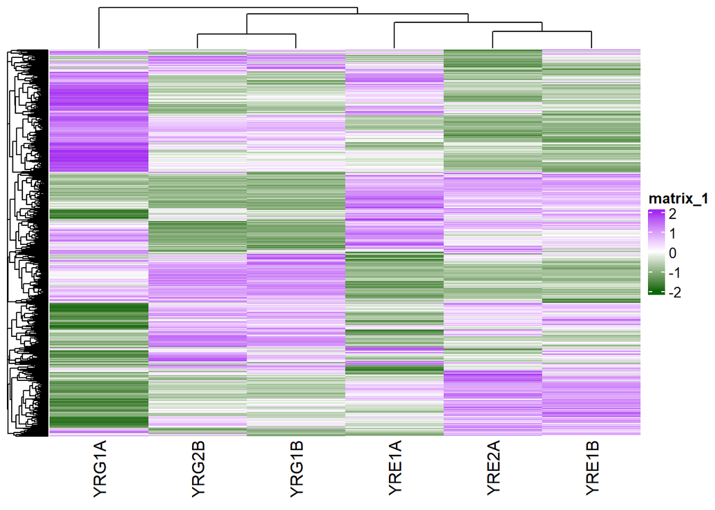

```r
if(min(heatmap_matrix) == 0){
   heatmap_col = circlize::colorRamp2(c( 0, max(heatmap_matrix)),
                           c("white", "purple"))
} else {
  heatmap_col = circlize::colorRamp2(c(min(heatmap_matrix), 0,
         max(heatmap_matrix)), c("darkgreen", "white", "purple"))
}
current_heatmap <- ComplexHeatmap::Heatmap(as.matrix(heatmap_matrix),
     show_row_dend = TRUE, show_column_dend = TRUE,
     col=heatmap_col, show_column_names = TRUE,
     show_row_names = FALSE, show_heatmap_legend = TRUE)
current_heatmap
```

### Part 4: SPP1 EMT Genes-Conclusion justification  
SPP1 is an EMT genes It shows higher expression when treated with GLI2 compare to empty vector control cells (EV). This has been also proved by the authors. However, indicating this again would strengthen the hypothesis corresponding to Dox treated cells having GLI2 vector show higher EMT gene expression as opposed to controls having empty vector showing less expression of the genes.

```r
GLI2_treatment_samples <- grep(colnames(normalized_count_data),
                              pattern = "\\G")
EV_tratment_samples <- grep(colnames(normalized_count_data),
                            pattern = "\\E")
gene_of_interest <- which(normalized_count_data$hgnc_symbol == "SPP1")

YAPC_GLI2_samples <- t(normalized_count_data[gene_of_interest,5:7])
colnames(YAPC_GLI2_samples) <- c("GLI2_vector_cells")

YAPC_EV_samples <- t(normalized_count_data[gene_of_interest,2:4])
colnames(YAPC_EV_samples) <- c("Empty_Vector_cells")

YAPC_EV_samples
```

```
##       Empty_Vector_cells
## YRE1A           1.307170
## YRE1B           1.616595
## YRE2A           1.752119
```

```r
YAPC_GLI2_samples
```

```
##       GLI2_vector_cells
## YRG1A          321.9614
## YRG1B          607.5096
## YRG2B          580.2982
```

### Part 5: T-test between EV and GLI2

GLI2 treated cells are different in terms of their expression from the empty vector cells. P value (0.03135) < 0.05. Indeed this shows there is significant difference. However, this requires to see if GLI2 treatments show difference among one another so the control cells.

```r
t.test(x=t(YAPC_GLI2_samples), y=t(YAPC_EV_samples))
```

```
##
##  Welch Two Sample t-test
##
## data:  t(YAPC_GLI2_samples) and t(YAPC_EV_samples)
## t = 5.5139, df = 2, p-value = 0.03135
## alternative hypothesis: true difference in means is not equal to 0
## 95 percent confidence interval:
##  110.2125 893.1831
## sample estimates:
##  mean of x  mean of y
## 503.256412   1.558628
```

### PART 6: MDS Plot for Sample Clustering

The MDS plot allowed to visualize the difference within the different cell types Earlier examples of MDS plot showed similar results. I hypothesize that GLI2 expression is higher than control cells’s expression levels due to DOX induction of EMT genes. In general I have observed Gli2 cells to be less clustered, due to higher differential expression among GLI2 cells.

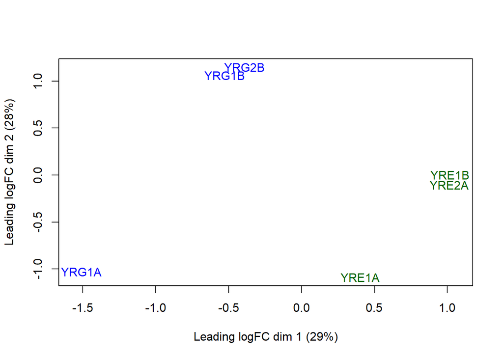

```r
limma::plotMDS(heatmap_matrix,col=c(rep("darkgreen",3),rep("blue",3)))
```

### Part 7: Model Building of GLI2 expression status The model I am building is based upon GLI2 expression status of genes that are showing higher expression with significant indications of the differential expression.

```r
samples <- data.frame(
           lapply(colnames(normalized_count_data)[2:7],
            FUN=function(x){
            unlist(strsplit(x, split= "[0-9]"))[c(1)]}))
colnames(samples) <- colnames(colnames(normalized_count_data)[2:7])
rownames(samples) <- c("Treatments")
samples <- data.frame(t(samples))
knitr::kable(samples,type = "pipe")
```

| Treatments |
| --- |
| YRE |
| YRE |
| YRE |
| YRG |
| YRG |
| YRG |

```r
model_design <- model.matrix( ~ samples$Treatments)
knitr::kable(model_design[1:6,],type = "pipe")
```

| (Intercept) | samples$TreatmentsYRG |
| --- | --- |
| 1 | 0 |
| 1 | 0 |
| 1 | 0 |
| 1 | 1 |
| 1 | 1 |
| 1 | 1 |

### Part 8: Model Fitting and Differential Expression Calcuation

The differential expression data matrix corresponding to gene symbols were merged with the matrix that has the fitted model. The Benjamin-hochberg correction method was applied to adjust the expression data.

```r
expressionMatrix <- as.matrix(normalized_count_data[,2:7])
rownames(expressionMatrix) <- normalized_count_data$hgnc_symbol
colnames(expressionMatrix) <- colnames(normalized_count_data)[2:7]
minimalSet <- Biobase::ExpressionSet(assayData = expressionMatrix)

fit <- limma::lmFit(minimalSet, model_design)

fit2 <- limma::eBayes(fit, trend = TRUE)

topfit <- limma::topTable(fit2,
                   coef=ncol(model_design),
                   adjust.method = "BH",
                   number = nrow(expressionMatrix))

output_hits <- merge(normalized_count_data$hgnc_symbol,
                     topfit,
                     by.y=0,by.x=1,
                     all.y=TRUE)

output_hits <- output_hits[order(output_hits$P.Value),]
colnames(output_hits) <- c("hgnc_symbol","logFC","AveExpr","t",
                           "P.Value","adj.P.Val","B")
rownames(output_hits) <- 1:nrow(output_hits)

knitr::kable(output_hits[1:10,1:7],type="html",row.names = FALSE,)
```

| hgnc_symbol | logFC | AveExpr | t | P.Value | adj.P.Val | B |
| --- | --- | --- | --- | --- | --- | --- |
| S100A2 | 192.67873 | 105.164286 | 63.79569 | 0e+00 | 0.0000245 | 1.820600 |
| SSFA2 | 76.45805 | 75.591839 | 45.17567 | 0e+00 | 0.0000789 | 1.781362 |
| NT5E | 86.27685 | 123.407858 | 42.93449 | 0e+00 | 0.0000789 | 1.773004 |
| S100A13 | 132.80964 | 179.285328 | 37.98876 | 0e+00 | 0.0001191 | 1.749192 |
| TRIB2 | 51.68968 | 38.062060 | 35.69100 | 1e-07 | 0.0001361 | 1.734718 |
| HEG1 | -13.44713 | 8.317468 | -31.24508 | 1e-07 | 0.0002423 | 1.697467 |
| NTN4 | 35.83705 | 33.048568 | 28.42566 | 2e-07 | 0.0003561 | 1.664696 |
| UCP2 | 80.78518 | 94.331418 | 26.66241 | 3e-07 | 0.0004488 | 1.638993 |
| PLLP | -31.42241 | 35.188668 | -25.42904 | 4e-07 | 0.0004683 | 1.617932 |
| UNC5B | 19.59576 | 12.041479 | 24.78963 | 5e-07 | 0.0004683 | 1.605831 |

### Part 9: P-value Assessment

The p-value was adjusted to have more stringent results. Normally significant p-value is set to 0.05. However, I wanted to be more stringent on my results and indicate the specific EMT genes. Probable genes are 741. However, there are 27 genes that have significant potential to be an EMT gene.

```r
length(which(output_hits$P.Value < 0.0005))
```

```
## [1] 741
```

```r
length(which(output_hits$adj.P.Val < 0.0005))
```

```
## [1] 27
```

### Part 10: Model Visualization

This part of this assignment aims to detect SPP1’s role on how GLI2 cells are more differently expressed and do have higher difference than the control cells. It is evident that, with more stringent p-value, the significant portion (741) of about 11500 genes are showing features of EMT genes

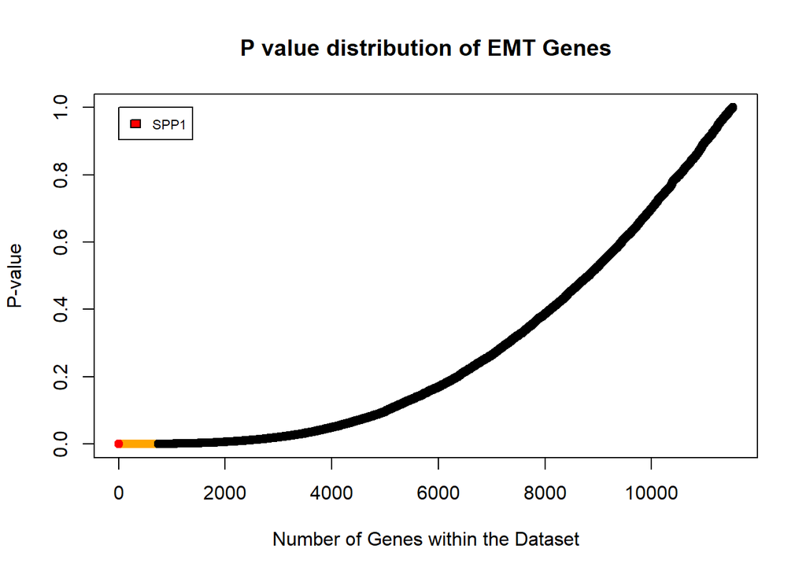

```r
model_pvalues <- data.frame(hgnc_symbol= output_hits$hgnc_symbol,
simple_pvalue= output_hits$P.Value)

model_pvalues$color <- "black"
  model_pvalues$color[
    model_pvalues$simple_pvalue < 0.0005] <- "orange"

hgnc_of_interest <- normalized_count_data$hgnc_symbol[which(normalized_count_data$hgnc_symbol == "SPP1")]
model_pvalues$color[model_pvalues$hgnc_symbol== hgnc_of_interest] <- "red"
plot(model_pvalues$simple_pvalue,
     col = model_pvalues$color,
     xlab = "Number of Genes within the Dataset",
     ylab ="P-value",
      main="P value distribution of EMT Genes")
points(model_pvalues[which(model_pvalues$hgnc_symbol == hgnc_of_interest), 1:2],
       pch = 20, col="red", cex=1.5)
legend(0,1,legend=c("SPP1"),
fill=c("red"),cex = 0.7)
```

### Part 11: Clustered Heatmap with More Stringent Values With more stringent gene size I was able to see cleaner difference between GLI2 and the control cells. The clustered genes are the symmetric each other across the diagonals. The high expression showing genes on the GLI2’s side is lower on the EV’ side. Top hits are assessed on the stringent p-value of 0.0005.

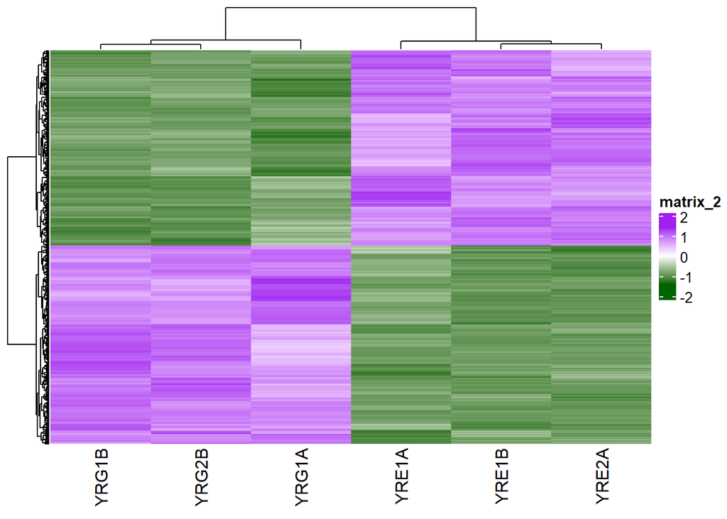

```r
top_hits <- output_hits$hgnc_symbol[output_hits$P.Value < 0.0005]
heatmap_matrix_tophits <- t(scale(t(heatmap_matrix[which(rownames(heatmap_matrix)
                       %in% top_hits),])))

if(min(heatmap_matrix_tophits) == 0){
heatmap_col = circlize::colorRamp2(c( 0, max(heatmap_matrix_tophits)),
                                   c( "white", "purple"))
} else {
heatmap_col = circlize::colorRamp2(c(min(heatmap_matrix_tophits), 0,
max(heatmap_matrix_tophits)), c("darkgreen", "white", "purple"))
}
newest_heatmap <- ComplexHeatmap::Heatmap(as.matrix(heatmap_matrix_tophits),
#cluster_rows = TRUE,
#cluster_columns = TRUE,
show_row_dend = TRUE,
show_column_dend = TRUE,
col=heatmap_col,
show_column_names = TRUE,
show_row_names = FALSE,
show_heatmap_legend = TRUE,)
newest_heatmap
```

### Part 13: Grouping Based on the Cell Types

The similar grouping was done previously. However this time dispersion values, normalization factors and differential expression model fitting is applied to the samples of GLI2 treatments.

```r
samples <- data.frame(lapply(colnames(GLI2_exp_filtered)[3:8],
                FUN=function(x){unlist(strsplit(x,split = "[0-9]"))[c(1)]}))
colnames(samples) <- colnames(GLI2_exp)[3:8]
rownames(samples) <- c("cell_type")
samples <- data.frame(t(samples))
d = edgeR::DGEList(counts=filtered_GLI2_matrix, group = samples$cell_type)

model_design_celltypes <- model.matrix(~samples$cell_type+0)
d <- edgeR::estimateDisp(d, model_design_celltypes)
d <- edgeR::calcNormFactors(d)
fit <- edgeR::glmQLFit(d, model_design_celltypes)
qlf.GLI2vsEV <- edgeR::glmQLFTest(fit, coef = "samples$cell_typeYRG")
```

### Part 14: Significant Results within the Fitted Model

```r
qlf_output_hits <- edgeR::topTags(qlf.GLI2vsEV,sort.by = "PValue",
                          n = nrow(filtered_GLI2_matrix))
head(qlf_output_hits)
```

```
## Coefficient:  samples$cell_typeYRG
##            logFC   logCPM         F       PValue         FDR
## ADAM15 -14.66671 5.427443 1252636.1 8.490905e-20 3.69538e-16
## LAMB1  -14.63332 5.416059 1201380.1 9.840552e-20 3.69538e-16
## RRAGA  -14.43536 5.426032 1033729.1 1.672979e-19 3.69538e-16
## SMAP2  -14.84240 5.427397  999721.4 1.882720e-19 3.69538e-16
## DDX18  -14.60997 5.420251  920508.0 2.519831e-19 3.69538e-16
## CASC4  -14.51764 5.430442  856813.3 3.245836e-19 3.69538e-16
```

```r
length(which(qlf_output_hits$table$PValue < 0.0005))
```

```
## [1] 2434
```

```r
length(which(qlf_output_hits$table$FDR < 0.0005))
```

```
## [1] 2433
```

### Part 15: Thresholded Gene List and Final EMT Gene Detection

```r
qlf_output_hits_withgn <- merge(GLI2_exp[,1:1],qlf_output_hits,
                 by.y=0,by.x=1,all.y=TRUE)

colnames(qlf_output_hits_withgn) <- c("hgnc_symbol","logFC","logCPM","F",
                                      "PValue","FDR")

qlf_output_hits_withgn[,"rank"] <- (-log(qlf_output_hits_withgn$PValue))
qlf_output_hits_withgn <- qlf_output_hits_withgn[order
                         (qlf_output_hits_withgn$hgnc_symbol),]

GLI2_emt_Genes <- qlf_output_hits_withgn$hgnc_symbol[
 which(qlf_output_hits_withgn$PValue < 0.0005
     & qlf_output_hits_withgn$logFC < 0)]
GLI2_non_emtgenes <- qlf_output_hits_withgn$hgnc_symbol[
 which(qlf_output_hits_withgn$PValue == 1)]

write.table(x=GLI2_emt_Genes, file = file.path(getwd(),"GLI2_emt_Genes.txt"),
            sep = "/", row.names = FALSE, col.names = FALSE, quote = FALSE)
write.table(x=GLI2_non_emtgenes, file = file.path(getwd(),"GLI2_non_emtgenes.txt"),
            sep = "/", row.names = FALSE, col.names = FALSE, quote = FALSE)
```

## Interpretation

#### Can you find evidence, i.e. publications, to support some of the results

that you see. How does this evidence support your results.

The paper (Pasca di Magliano et al.,2006) has already indicated increase expression of GLI2 can lead to SHH gene reduction. This gene has been known to be an oncogene associated with basal-subtype switching in PDAC. They activate GLI2 constantly which has the same expected outcome in our dataset having GLI2 expressing vectors with constant Dox treatment. In conclusion these two paper findings correlate each other.

## References

Adams, Christina R, Htet Htwe Htwe, Timothy Marsh, Aprilgate L Wang, Megan L Montoya, Lakshmipriya Subbaraj, Aaron D Tward, Nabeel Bardeesy, and Rushika M Perera. 2019. “Transcriptional Control of Subtype Switching Ensures Adaptation and Growth of Pancreatic Cancer.” *Elife* 8: e45313.

Allaire, JJ, Yihui Xie, Jonathan McPherson, Javier Luraschi, Kevin Ushey, Aron Atkins, Hadley Wickham, Joe Cheng, Winston Chang, and Richard Iannone. 2021. *rmarkdown: Dynamic Documents for R*. https://github.com/rstudio/rmarkdown.

Davis, S., and P. Meltzer. 2007. “GEOquery: A Bridge Between the Gene Expression Omnibus (GEO) and BioConductor.” *Bioinformatics* 14: 1846–47.

Durinck, S., P. Spellman, E. Birney, and W. Huber. 2009. “Mapping Identifiers for the Integration of Genomic Datasets with the r/Bioconductor Package biomaRt.” *Nature Protocols* 4: 1184–91.

Gu, Zuguang. 2022. “Complex Heatmap Visualization.” *iMeta* 1 (3): e43.

Gu, Zuguang, Lei Gu, Roland Eils, Matthias Schlesner, and Benedikt Brors. 2014. “Circlize Implements and Enhances Circular Visualization in r.” *Bioinformatics* 30 (19): 2811–12.

Magliano, Marina Pasca di, Shigeki Sekine, Alexandre Ermilov, Jenny Ferris, Andrzej A Dlugosz, and Matthias Hebrok. 2006. “Hedgehog/Ras Interactions Regulate Early Stages of Pancreatic Cancer.” *Genes & Development* 20 (22): 3161–73.

R Core Team. 2022. *R: A Language and Environment for Statistical Computing*. Vienna, Austria: R Foundation for Statistical Computing. https://www.R-project.org/.

Ritchie, Matthew E, Belinda Phipson, DI Wu, Yifang Hu, Charity W Law, Wei Shi, and Gordon K Smyth. 2015. “Limma Powers Differential Expression Analyses for RNA-Sequencing and Microarray Studies.” *Nucleic Acids Research* 43 (7): e47–47.

Robinson, M. D., McCarthy DJ, and G. K. Smyth. 2010. “edgeR: A Bioconductor Package for Differential Expression Analysis of Digital Gene Expression Data.” *Bioinformatics* 26: 139–40.